# Dog_Classification

## Dog Classification Project Udacity Deep Learning NanoDegree 2020

```python
import numpy as np
from glob import glob

# load filenames for human and dog images
human_files = np.array(glob("lfw/*/*"))
dog_files = np.array(glob("dogImages/*/*/*"))

# print number of images in each dataset
print('There are %d total human images.' % len(human_files))
print('There are %d total dog images.' % len(dog_files))
```

```
There are 13233 total human images.
There are 8351 total dog images.
```

```
Number of faces detected: 1
```

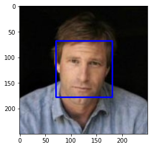

```python
import cv2 # opencv-contrib-python must be installed
import matplotlib.pyplot as plt
%matplotlib inline

# extract pre-trained face detector
face_cascade = cv2.CascadeClassifier('haarcascades/haarcascade_frontalface_alt.xml')

# load color (BGR) image
img = cv2.imread(human_files[0])
# convert BGR image to grayscale
gray = cv2.cvtColor(img, cv2.COLOR_BGR2GRAY)

# find faces in image
faces = face_cascade.detectMultiScale(gray)

# print number of faces detected in the image
print('Number of faces detected:', len(faces))

# get bounding box for each detected face
for (x,y,w,h) in faces:
    # add bounding box to color image
    cv2.rectangle(img,(x,y),(x+w,y+h),(255,0,0),2)

# convert BGR image to RGB for plotting
cv_rgb = cv2.cvtColor(img, cv2.COLOR_BGR2RGB)

# display the image, along with bounding box
plt.imshow(cv_rgb)
plt.show()
```

```python
# returns "True" if face is detected in image stored at img_path
def face_detector(img_path):
    img = cv2.imread(img_path)
    gray = cv2.cvtColor(img, cv2.COLOR_BGR2GRAY)
    faces = face_cascade.detectMultiScale(gray)
    return len(faces) > 0
```

## Answer1: detect face in human_files in %: 97.0% detect face in dog_files in %: 18.88%

```python
from tqdm import tqdm

human_files_short = human_files[:200]
dog_files_short = dog_files[:90]

def face_detection_test(files):
    detection_cnt = 0;
    total_cnt = len(files)
    for file in files:
        detection_cnt += face_detector(file)
    return detection_cnt, total_cnt
print("detect face in human_files in %: "+str(((face_detection_test(human_files_short)[0])/(face_detection_test(human_files_short)[1]))*100)+"%")
print("detect face in dog_files in %: "+str(((face_detection_test(dog_files_short)[0])/(face_detection_test(dog_files_short)[1]))*100)+"%")
```

```
detect face in human_files in %: 97.0%
detect face in dog_files in %: 18.88888888888889%
```

```python
import torch
import torchvision.models as models

# define VGG16 model
VGG16 = models.vgg16(pretrained=True)

# check if CUDA is available
use_cuda = torch.cuda.is_available()

# move model to GPU if CUDA is available
if use_cuda:
    VGG16 = VGG16.cuda()
```

```python
from PIL import Image
import torchvision.transforms as transforms

def VGG16_predict(img_path):
    '''
    Use pre-trained VGG-16 model to obtain index corresponding to
    predicted ImageNet class for image at specified path

    Args:
        img_path: path to an image

    Returns:
        Index corresponding to VGG-16 model's prediction
    '''
    image = Image.open(img_path).convert('RGB')
    in_transform = transforms.Compose([
                        transforms.Resize(size=(244, 244)),
                        transforms.ToTensor()])


    image = in_transform(image)[:3,:,:].unsqueeze(0)

    img = image
    if use_cuda:
        img = img.cuda()
    ret = VGG16(img)
    return torch.max(ret,1)[1].item() # predicted class index
```

```python
### returns "True" if a dog is detected in the image stored at img_path
def dog_detector(img_path):
    ky = VGG16_predict(img_path)
    return ky > 151 and ky <= 276 # true/false
```

```python
print(dog_detector(dog_files_short[0]))
print(dog_detector(human_files_short[0]))
```

```
True
False
```

## Answer2: detect dog in human_files in %: 0.0% detect dog in dog_files in %: 94.44%

```python
def dog_detectorv2(files):
    detection_cnt = 0;
    total_cnt = len(files)
    for file in files:
        detection_cnt += dog_detector(file)
    return detection_cnt, total_cnt

print("detect dog in human_files in %: "+str(((dog_detectorv2(human_files_short)[0])/(dog_detectorv2(human_files_short)[1]))*100)+"%")
print("detect dog in dog_files in %: "+str(((dog_detectorv2(dog_files_short)[0])/(dog_detectorv2(dog_files_short)[1]))*100)+"%")
```

```
detect dog in human_files in %: 0.0%
detect dog in dog_files in %: 94.44444444444444%
```

```python
import os
import pandas as pd
import numpy as np
import os
import torchvision
from torchvision import datasets, transforms, models

from PIL import Image
from collections import OrderedDict

import matplotlib.pyplot as plt

%matplotlib inline
```

```python
data_dir = "./dogImages"
train_dir = "./dogImages/train"
valid_dir = "./dogImages/valid"
test_dir = "./dogImages/test"

data_transforms = {
    'train': transforms.Compose([
        transforms.ColorJitter(brightness=0.2, hue=.1, saturation=.1),
        transforms.RandomRotation(30),
        transforms.RandomHorizontalFlip(),
        transforms.RandomVerticalFlip(),
        transforms.Resize(256),
        transforms.RandomResizedCrop(224),
        transforms.ToTensor(),
        transforms.Normalize([0.485, 0.456, 0.406],
                             [0.229, 0.224, 0.225])
    ]),
    'valid': transforms.Compose([
        transforms.Resize(256),
        transforms.CenterCrop(224),
        transforms.ToTensor(),
        transforms.Normalize([0.485, 0.456, 0.406],
                             [0.229, 0.224, 0.225])
    ]),
    'test': transforms.Compose([
        transforms.Resize(256),
        transforms.CenterCrop(224),
        transforms.ToTensor(),
        transforms.Normalize([0.485, 0.456, 0.406],
                             [0.229, 0.224, 0.225])
    ])
    }

dirs = {'train': train_dir,
        'valid': valid_dir,
        'test': test_dir}

datasets = {x: torchvision.datasets.ImageFolder(dirs[x], transform=data_transforms[x]) for x in ['train', 'valid', 'test']}

dataloaders = {x: torch.utils.data.DataLoader(datasets[x], batch_size=22, shuffle=True, num_workers=0) for x in ['train', 'valid','test']}

dataset_sizes = {x: len(datasets[x]) for x in ['train', 'valid','test']}
print(dataset_sizes)
```

```
{'train': 6680, 'valid': 835, 'test': 836}
```

## Answer3: I guess what I did could avoid the overfitting. I used transforms.RandomRotation(30), transforms.RandomHorizontalFlip(), transforms.RandomVerticalFlip() to best perform the dataset. I'd also done Resize of (256) and then, center crop to make 224 X 224. Image augmentation gives randomness to the dataset and a better performance of model when it's predicting toward test_data.

```python
import torch
import torch.nn as nn
import torch.nn.functional as F
from torch.optim import lr_scheduler
from torch.autograd import Variable
from torch.utils.data.sampler import SubsetRandomSampler
from torchvision import datasets, models, transforms
from PIL import ImageFile
ImageFile.LOAD_TRUNCATED_IMAGES = True

# define the CNN architecture
class Net(nn.Module):
    ### TODO: choose an architecture, and complete the class
    def __init__(self):
        super(Net, self).__init__()
        ## Define layers of a CNN
        self.conv1 = nn.Conv2d(3, 32, 3, stride=2, padding=1)
        self.conv2 = nn.Conv2d(32, 64, 3, stride=2, padding=1)
        self.conv3 = nn.Conv2d(64, 128, 3, padding=1)

        # pool
        self.pool = nn.MaxPool2d(2, 2)

        # fully-connected
        self.fc1 = nn.Linear(7*7*128, 500)
        self.fc2 = nn.Linear(500, 133)

        # drop-out
        self.dropout = nn.Dropout(0.3)

    def forward(self, x):
        ## Define forward behavior
        x = F.relu(self.conv1(x))
        x = self.pool(x)
        x = F.relu(self.conv2(x))
        x = self.pool(x)
        x = F.relu(self.conv3(x))
        x = self.pool(x)

        # flatten
        x = x.view(-1, 7*7*128)

        x = self.dropout(x)
        x = F.relu(self.fc1(x))

        x = self.dropout(x)
        x = self.fc2(x)
        return x

#-#-# You so NOT have to modify the code below this line. #-#-#

# instantiate the CNN
model_scratch = Net()

# move tensors to GPU if CUDA is available
if use_cuda:
    model_scratch.cuda()
```

```python
print(model_scratch)
```

```
Net(
  (conv1): Conv2d(3, 32, kernel_size=(3, 3), stride=(2, 2), padding=(1, 1))
  (conv2): Conv2d(32, 64, kernel_size=(3, 3), stride=(2, 2), padding=(1, 1))
  (conv3): Conv2d(64, 128, kernel_size=(3, 3), stride=(1, 1), padding=(1, 1))
  (pool): MaxPool2d(kernel_size=2, stride=2, padding=0, dilation=1, ceil_mode=False)
  (fc1): Linear(in_features=6272, out_features=500, bias=True)
  (fc2): Linear(in_features=500, out_features=133, bias=True)
  (dropout): Dropout(p=0.3, inplace=False)
)
```

## Answer4: I created a kernel_size of 3 with stride 2 and 1 for the first conv layers. After that, maxpooling with stride 2 is placed to downsize of input image by 2. The output image size is downsized by factor of 32 and the depth, 128. Dropout of 0.3 in order to prevent overfitting. Fully-connected layer is placed and then, 2nd fully-connected layer is intended to produce final output_size.

```python
import torch.optim as optim

criterion_scratch = nn.CrossEntropyLoss()

optimizer_scratch = optim.SGD(model_scratch.parameters(), lr = 0.1)
```

```python
def train(n_epochs, loaders, model, optimizer, criterion, use_cuda, save_path, last_validation_loss=None):
    """returns trained model"""
    # initialize tracker for minimum validation loss
    if last_validation_loss is not None:
        valid_loss_min = last_validation_loss
    else:
        valid_loss_min = np.Inf

    for epoch in range(1, n_epochs+1):
        # initialize variables to monitor training and validation loss
        train_loss = 0.0
        valid_loss = 0.0

        ###################
        # train the model #
        ###################
        model.train()
        for batch_idx, (data, target) in enumerate(loaders['train']):
            # move to GPU
            if use_cuda:
                data, target = data.cuda(), target.cuda()
            ## find the loss and update the model parameters accordingly
            ## record the average training loss, using something like
            ## train_loss = train_loss + ((1 / (batch_idx + 1)) * (loss.data - train_loss))

            # initialize weights to zero
            optimizer.zero_grad()

            output = model(data)

            # calculate loss
            loss = criterion(output, target)

            # back prop
            loss.backward()

            # grad
            optimizer.step()

            train_loss = train_loss + ((1 / (batch_idx + 1)) * (loss.data - train_loss))

            if batch_idx % 100 == 0:
                print('Epoch %d, Batch %d loss: %.6f' %
                  (epoch, batch_idx + 1, train_loss))

        ######################
        # validate the model #
        ######################
        model.eval()
        for batch_idx, (data, target) in enumerate(loaders['valid']):
            # move to GPU
            if use_cuda:
                data, target = data.cuda(), target.cuda()
            ## update the average validation loss
            output = model(data)
            loss = criterion(output, target)
            valid_loss = valid_loss + ((1 / (batch_idx + 1)) * (loss.data - valid_loss))


        # print training/validation statistics
        print('Epoch: {} \tTraining Loss: {:.6f} \tValidation Loss: {:.6f}'.format(
            epoch,
            train_loss,
            valid_loss
            ))

        ## TODO: save the model if validation loss has decreased
        if valid_loss < valid_loss_min:
            torch.save(model.state_dict(), save_path)
            print('Validation loss decreased ({:.6f} --> {:.6f}).  Saving model ...'.format(
            valid_loss_min,
            valid_loss))
            valid_loss_min = valid_loss

    # return trained model
    return model
```

```python
# train the model
use_cuda = torch.cuda.is_available()
model_scratch = train(35, dataloaders, model_scratch, optimizer_scratch,
                      criterion_scratch, use_cuda, 'model_scratch.pt')
# load the model that got the best validation accuracy
model_scratch.load_state_dict(torch.load('model_scratch.pt'))
```

```
Epoch 1, Batch 1 loss: 4.912932
Epoch 1, Batch 101 loss: 4.886968
Epoch 1, Batch 201 loss: 4.882233
Epoch 1, Batch 301 loss: 4.871651
Epoch: 1 	Training Loss: 4.871354 	Validation Loss: 4.801960
Validation loss decreased (inf --> 4.801960).  Saving model ...
Epoch 2, Batch 1 loss: 4.743663
Epoch 2, Batch 101 loss: 4.801980
Epoch 2, Batch 201 loss: 4.772338
Epoch 2, Batch 301 loss: 4.758562
Epoch: 2 	Training Loss: 4.758744 	Validation Loss: 4.649820
Validation loss decreased (4.801960 --> 4.649820).  Saving model ...
Epoch 3, Batch 1 loss: 4.756925
Epoch 3, Batch 101 loss: 4.698272
Epoch 3, Batch 201 loss: 4.702345
Epoch 3, Batch 301 loss: 4.695961
Epoch: 3 	Training Loss: 4.694497 	Validation Loss: 4.506127
Validation loss decreased (4.649820 --> 4.506127).  Saving model ...
Epoch 4, Batch 1 loss: 4.704853
Epoch 4, Batch 101 loss: 4.640727
Epoch 4, Batch 201 loss: 4.638043
Epoch 4, Batch 301 loss: 4.637670
Epoch: 4 	Training Loss: 4.637913 	Validation Loss: 4.468289
Validation loss decreased (4.506127 --> 4.468289).  Saving model ...
Epoch 5, Batch 1 loss: 4.468668
Epoch 5, Batch 101 loss: 4.602338
Epoch 5, Batch 201 loss: 4.596026
Epoch 5, Batch 301 loss: 4.593620
Epoch: 5 	Training Loss: 4.594312 	Validation Loss: 4.420263
Validation loss decreased (4.468289 --> 4.420263).  Saving model ...
Epoch 6, Batch 1 loss: 4.371617
Epoch 6, Batch 101 loss: 4.573105
Epoch 6, Batch 201 loss: 4.567294
Epoch 6, Batch 301 loss: 4.558479
Epoch: 6 	Training Loss: 4.559339 	Validation Loss: 4.410610
Validation loss decreased (4.420263 --> 4.410610).  Saving model ...
Epoch 7, Batch 1 loss: 4.534246
Epoch 7, Batch 101 loss: 4.501514
Epoch 7, Batch 201 loss: 4.499060
Epoch 7, Batch 301 loss: 4.502822
```

[output cut: 139 more lines]

```
Epoch 33, Batch 101 loss: 3.925223
Epoch 33, Batch 201 loss: 3.949111
Epoch 33, Batch 301 loss: 3.957010
Epoch: 33 	Training Loss: 3.955661 	Validation Loss: 3.934543
Epoch 34, Batch 1 loss: 4.497696
Epoch 34, Batch 101 loss: 3.945018
Epoch 34, Batch 201 loss: 3.945687
Epoch 34, Batch 301 loss: 3.949056
Epoch: 34 	Training Loss: 3.949670 	Validation Loss: 3.654412
Validation loss decreased (3.660056 --> 3.654412).  Saving model ...
Epoch 35, Batch 1 loss: 3.596533
Epoch 35, Batch 101 loss: 3.892499
Epoch 35, Batch 201 loss: 3.914127
Epoch 35, Batch 301 loss: 3.934064
Epoch: 35 	Training Loss: 3.934306 	Validation Loss: 3.831344
```

```
<All keys matched successfully>
```

```python
def test(loaders, model, criterion, use_cuda):

    # monitor test loss and accuracy
    test_loss = 0.
    correct = 0.
    total = 0.

    model.eval()
    for batch_idx, (data, target) in enumerate(loaders['test']):
        # move to GPU
        if use_cuda:
            data, target = data.cuda(), target.cuda()
        # forward pass: compute predicted outputs by passing inputs to the model
        output = model(data)
        # calculate the loss
        loss = criterion(output, target)
        # update average test loss
        test_loss = test_loss + ((1 / (batch_idx + 1)) * (loss.data - test_loss))
        # convert output probabilities to predicted class
        pred = output.data.max(1, keepdim=True)[1]
        # compare predictions to true label
        correct += np.sum(np.squeeze(pred.eq(target.data.view_as(pred))).cpu().numpy())
        total += data.size(0)

    print('Test Loss: {:.6f}\n'.format(test_loss))

    print('\nTest Accuracy: %2d%% (%2d/%2d)' % (
        100. * correct / total, correct, total))

# call test function
test(dataloaders, model_scratch, criterion_scratch, use_cuda)
```

```
Test Loss: 3.639330


Test Accuracy: 13% (115/836)
```

```python
loaders_transfer = dataloaders.copy()
```

```python
import torchvision.models as models
import torch.nn as nn

model_transfer = models.resnet50(pretrained=True)

for param in model_transfer.parameters():
    param.requires_grad = False

model_transfer.fc = nn.Linear(2048, 133, bias=True)

fc_parameters = model_transfer.fc.parameters()

for param in fc_parameters:
    param.requires_grad = True

model_transfer
```

```
Downloading: "https://download.pytorch.org/models/resnet50-19c8e357.pth" to C:\Users\alcar/.cache\torch\checkpoints\resnet50-19c8e357.pth
```

```
ResNet(
  (conv1): Conv2d(3, 64, kernel_size=(7, 7), stride=(2, 2), padding=(3, 3), bias=False)
  (bn1): BatchNorm2d(64, eps=1e-05, momentum=0.1, affine=True, track_running_stats=True)
  (relu): ReLU(inplace=True)
  (maxpool): MaxPool2d(kernel_size=3, stride=2, padding=1, dilation=1, ceil_mode=False)
  (layer1): Sequential(
    (0): Bottleneck(
      (conv1): Conv2d(64, 64, kernel_size=(1, 1), stride=(1, 1), bias=False)
      (bn1): BatchNorm2d(64, eps=1e-05, momentum=0.1, affine=True, track_running_stats=True)
      (conv2): Conv2d(64, 64, kernel_size=(3, 3), stride=(1, 1), padding=(1, 1), bias=False)
      (bn2): BatchNorm2d(64, eps=1e-05, momentum=0.1, affine=True, track_running_stats=True)
      (conv3): Conv2d(64, 256, kernel_size=(1, 1), stride=(1, 1), bias=False)
      (bn3): BatchNorm2d(256, eps=1e-05, momentum=0.1, affine=True, track_running_stats=True)
      (relu): ReLU(inplace=True)
      (downsample): Sequential(
        (0): Conv2d(64, 256, kernel_size=(1, 1), stride=(1, 1), bias=False)
        (1): BatchNorm2d(256, eps=1e-05, momentum=0.1, affine=True, track_running_stats=True)
      )
    )
    (1): Bottleneck(
      (conv1): Conv2d(256, 64, kernel_size=(1, 1), stride=(1, 1), bias=False)
      (bn1): BatchNorm2d(64, eps=1e-05, momentum=0.1, affine=True, track_running_stats=True)
      (conv2): Conv2d(64, 64, kernel_size=(3, 3), stride=(1, 1), padding=(1, 1), bias=False)
      (bn2): BatchNorm2d(64, eps=1e-05, momentum=0.1, affine=True, track_running_stats=True)
      (conv3): Conv2d(64, 256, kernel_size=(1, 1), stride=(1, 1), bias=False)
      (bn3): BatchNorm2d(256, eps=1e-05, momentum=0.1, affine=True, track_running_stats=True)
      (relu): ReLU(inplace=True)
    )
    (2): Bottleneck(
      (conv1): Conv2d(256, 64, kernel_size=(1, 1), stride=(1, 1), bias=False)
      (bn1): BatchNorm2d(64, eps=1e-05, momentum=0.1, affine=True, track_running_stats=True)
      (conv2): Conv2d(64, 64, kernel_size=(3, 3), stride=(1, 1), padding=(1, 1), bias=False)
      (bn2): BatchNorm2d(64, eps=1e-05, momentum=0.1, affine=True, track_running_stats=True)
      (conv3): Conv2d(64, 256, kernel_size=(1, 1), stride=(1, 1), bias=False)
      (bn3): BatchNorm2d(256, eps=1e-05, momentum=0.1, affine=True, track_running_stats=True)
      (relu): ReLU(inplace=True)
    )
  )
  (layer2): Sequential(
    (0): Bottleneck(
```

[output cut: 121 more lines]

```
      (relu): ReLU(inplace=True)
    )
    (2): Bottleneck(
      (conv1): Conv2d(2048, 512, kernel_size=(1, 1), stride=(1, 1), bias=False)
      (bn1): BatchNorm2d(512, eps=1e-05, momentum=0.1, affine=True, track_running_stats=True)
      (conv2): Conv2d(512, 512, kernel_size=(3, 3), stride=(1, 1), padding=(1, 1), bias=False)
      (bn2): BatchNorm2d(512, eps=1e-05, momentum=0.1, affine=True, track_running_stats=True)
      (conv3): Conv2d(512, 2048, kernel_size=(1, 1), stride=(1, 1), bias=False)
      (bn3): BatchNorm2d(2048, eps=1e-05, momentum=0.1, affine=True, track_running_stats=True)
      (relu): ReLU(inplace=True)
    )
  )
  (avgpool): AdaptiveAvgPool2d(output_size=(1, 1))
  (fc): Linear(in_features=2048, out_features=133, bias=True)
)
```

```python
if use_cuda:
    model_transfer = model_transfer.cuda()
```

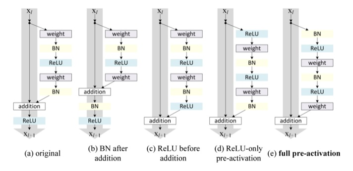

## (a) original bottleneck residual module. (e) full pre-activation residual module. Called pre-activation because BN and ReLU layers occur before the convolutions.

## Answer5: I'd applied ResNet as a transfer model because it prevents overfitting when it's training. ResNet stands for Residual Network and more specifically it is of a Residual Neural Network architecture. What characterizes a residual network is its identity connections. Identity connections takes the input directly to the end of each residual block. A much more complex CNN architecture maybe correct (adjust) small dataset distributions. ResNet worked trying to “skip connections” and features heavy batch normalization. ResNet has residual connections. The basic building block for ResNets are the conv and identity blocks. Bottleneck would reduce the dimensionality in the first two CONV layers (1/4 of the filters learned in the final CONV layer) and then increase again during the final CONV layer. It designs even deeper CNNs (up to 152 layers) without compromising model’s generalisation power. The ResNet model consists of 5 stages each with a residual block. Each residual block has 3 layers with both 11 and 33 convolutions. See https://arxiv.org/abs/1512.03385 https://en.wikipedia.org/wiki/Residual_neural_network

```python
criterion_transfer = nn.CrossEntropyLoss()
optimizer_transfer = optim.SGD(model_transfer.fc.parameters(), lr=0.01)
```

```python
# train the model
model_transfer = train(20, loaders_transfer, model_transfer, optimizer_transfer, criterion_transfer, use_cuda, 'model_transfer.pt')

# load the model that got the best validation accuracy (uncomment the line below)
model_transfer.load_state_dict(torch.load('model_transfer.pt'))
```

```
Epoch 1, Batch 1 loss: 4.985304
Epoch 1, Batch 101 loss: 4.798306
Epoch 1, Batch 201 loss: 4.666036
Epoch 1, Batch 301 loss: 4.540394
Epoch: 1 	Training Loss: 4.536283 	Validation Loss: 3.682971
Validation loss decreased (inf --> 3.682971).  Saving model ...
Epoch 2, Batch 1 loss: 4.163915
Epoch 2, Batch 101 loss: 3.992607
Epoch 2, Batch 201 loss: 3.912102
Epoch 2, Batch 301 loss: 3.821654
Epoch: 2 	Training Loss: 3.818513 	Validation Loss: 2.751429
Validation loss decreased (3.682971 --> 2.751429).  Saving model ...
Epoch 3, Batch 1 loss: 3.619802
Epoch 3, Batch 101 loss: 3.439246
Epoch 3, Batch 201 loss: 3.387634
Epoch 3, Batch 301 loss: 3.333284
Epoch: 3 	Training Loss: 3.330951 	Validation Loss: 2.172674
Validation loss decreased (2.751429 --> 2.172674).  Saving model ...
Epoch 4, Batch 1 loss: 3.063603
Epoch 4, Batch 101 loss: 3.077952
Epoch 4, Batch 201 loss: 3.032572
Epoch 4, Batch 301 loss: 2.974213
Epoch: 4 	Training Loss: 2.975389 	Validation Loss: 1.725453
Validation loss decreased (2.172674 --> 1.725453).  Saving model ...
Epoch 5, Batch 1 loss: 2.851504
Epoch 5, Batch 101 loss: 2.756462
Epoch 5, Batch 201 loss: 2.721994
Epoch 5, Batch 301 loss: 2.706143
Epoch: 5 	Training Loss: 2.706185 	Validation Loss: 1.470856
Validation loss decreased (1.725453 --> 1.470856).  Saving model ...
Epoch 6, Batch 1 loss: 2.441519
Epoch 6, Batch 101 loss: 2.528277
Epoch 6, Batch 201 loss: 2.529816
Epoch 6, Batch 301 loss: 2.505248
Epoch: 6 	Training Loss: 2.503608 	Validation Loss: 1.288299
Validation loss decreased (1.470856 --> 1.288299).  Saving model ...
Epoch 7, Batch 1 loss: 2.215901
Epoch 7, Batch 101 loss: 2.419154
Epoch 7, Batch 201 loss: 2.388446
Epoch 7, Batch 301 loss: 2.364247
```

[output cut: 65 more lines]

```
Epoch 18, Batch 301 loss: 1.745687
Epoch: 18 	Training Loss: 1.748526 	Validation Loss: 0.665414
Validation loss decreased (0.672774 --> 0.665414).  Saving model ...
Epoch 19, Batch 1 loss: 1.590765
Epoch 19, Batch 101 loss: 1.700683
Epoch 19, Batch 201 loss: 1.725222
Epoch 19, Batch 301 loss: 1.722066
Epoch: 19 	Training Loss: 1.720456 	Validation Loss: 0.640258
Validation loss decreased (0.665414 --> 0.640258).  Saving model ...
Epoch 20, Batch 1 loss: 1.874180
Epoch 20, Batch 101 loss: 1.684493
Epoch 20, Batch 201 loss: 1.701118
Epoch 20, Batch 301 loss: 1.697395
Epoch: 20 	Training Loss: 1.697340 	Validation Loss: 0.627320
Validation loss decreased (0.640258 --> 0.627320).  Saving model ...
```

```
<All keys matched successfully>
```

```python
test(loaders_transfer, model_transfer, criterion_transfer, use_cuda)
```

```
Test Loss: 0.625031


Test Accuracy: 83% (697/836)
```

```python
class_names = [item[4:].replace("_", " ") for item in loaders_transfer['train'].dataset.classes]

loaders_transfer['train'].dataset.classes[:10]
```

```
['001.Affenpinscher',
 '002.Afghan_hound',
 '003.Airedale_terrier',
 '004.Akita',
 '005.Alaskan_malamute',
 '006.American_eskimo_dog',
 '007.American_foxhound',
 '008.American_staffordshire_terrier',
 '009.American_water_spaniel',
 '010.Anatolian_shepherd_dog']
```

```python
standard_normalization = transforms.Normalize(mean=[0.485, 0.456, 0.406],
                                              std=[0.229, 0.224, 0.225])
```

```python
def load_input_image(img_path):
    image = Image.open(img_path).convert('RGB')
    prediction_transform = transforms.Compose([transforms.Resize(size=(224, 224)),
                                     transforms.ToTensor(),
                                     standard_normalization])

    # discard the transparent, alpha channel (that's the :3) and add the batch dimension
    image = prediction_transform(image)[:3,:,:].unsqueeze(0)
    return image
def predict_breed_transfer(model, class_names, img_path):
    # load the image and return the predicted breed
    img = load_input_image(img_path)
    model = model.cpu()
    model.eval()
    idx = torch.argmax(model(img))
    return class_names[idx]
for img_file in os.listdir('./dogImages/test/001.Affenpinscher'):
    img_path = os.path.join('./dogImages/test/001.Affenpinscher', img_file)
    predition = predict_breed_transfer(model_transfer, class_names, img_path)
    print("image_file_name: {0}, \t predition breed: {1}".format(img_path, predition))
```

```
image_file_name: ./dogImages/test/001.Affenpinscher\Affenpinscher_00003.jpg, 	 predition breed: Affenpinscher
image_file_name: ./dogImages/test/001.Affenpinscher\Affenpinscher_00023.jpg, 	 predition breed: Affenpinscher
image_file_name: ./dogImages/test/001.Affenpinscher\Affenpinscher_00036.jpg, 	 predition breed: Brussels griffon
image_file_name: ./dogImages/test/001.Affenpinscher\Affenpinscher_00047.jpg, 	 predition breed: Affenpinscher
image_file_name: ./dogImages/test/001.Affenpinscher\Affenpinscher_00048.jpg, 	 predition breed: Affenpinscher
image_file_name: ./dogImages/test/001.Affenpinscher\Affenpinscher_00058.jpg, 	 predition breed: Lhasa apso
image_file_name: ./dogImages/test/001.Affenpinscher\Affenpinscher_00071.jpg, 	 predition breed: Affenpinscher
image_file_name: ./dogImages/test/001.Affenpinscher\Affenpinscher_00078.jpg, 	 predition breed: Affenpinscher
```

```python
def run_app(img_path):
    ## handle cases for a human face, dog, and neither
    img = Image.open(img_path)
    plt.imshow(img)
    plt.show()
    if dog_detector(img_path) is True:
        prediction = predict_breed_transfer(model_transfer, class_names, img_path)
        print("Dogs Detected!\nIt looks like a {0}".format(prediction))
    elif face_detector(img_path) > 0:
        prediction = predict_breed_transfer(model_transfer, class_names, img_path)
        print("Hello, human!\nIf you were a dog..You may look like a {0}".format(prediction))
    else:
        print("Error! Can't detect anything..")
```

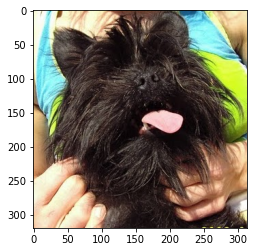

```
Error! Can't detect anything..
```

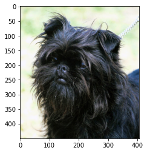

```
Dogs Detected!
It looks like a Affenpinscher
```

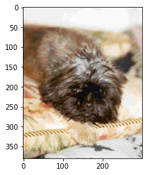

```
Dogs Detected!
It looks like a Brussels griffon
```

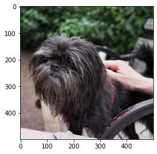

```
Dogs Detected!
It looks like a Affenpinscher
```

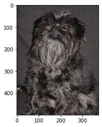

```
Dogs Detected!
It looks like a Affenpinscher
```

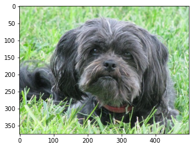

```
Dogs Detected!
It looks like a Lhasa apso
```

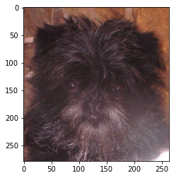

```
Error! Can't detect anything..
```

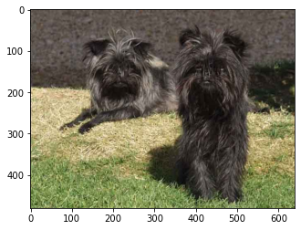

```
Dogs Detected!
It looks like a Affenpinscher
```

```python
for img_file in os.listdir('./dogImages/test/001.Affenpinscher'):
    img_path = os.path.join('./dogImages/test/001.Affenpinscher', img_file)
    run_app(img_path)
```

## Answer6: Better than I expected. Points of improvement: dataloaders must operate with num_workers > 0, Workspace must run faster and datasets should be higher.

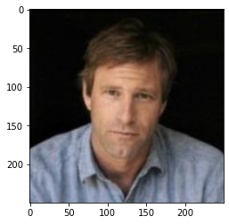

```
Hello, human!
If you were a dog..You may look like a French bulldog
```

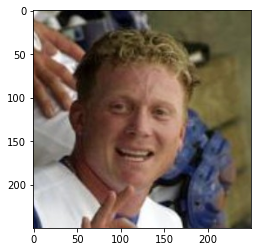

```
Hello, human!
If you were a dog..You may look like a Dogue de bordeaux
```

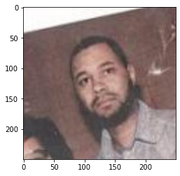

```
Error! Can't detect anything..
```

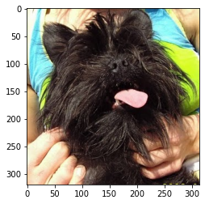

```
Error! Can't detect anything..
```

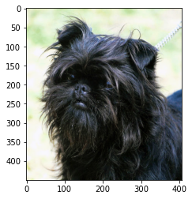

```
Dogs Detected!
It looks like a Affenpinscher
```

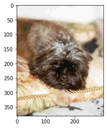

```
Dogs Detected!
It looks like a Brussels griffon
```

```python
for file in np.hstack((human_files[:3], dog_files[:3])):
    run_app(file)
```

[figure not shown]

```
Hello, human!
If you were a dog..You may look like a Cardigan welsh corgi
```

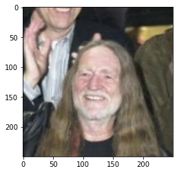

```
Hello, human!
If you were a dog..You may look like a Neapolitan mastiff
```

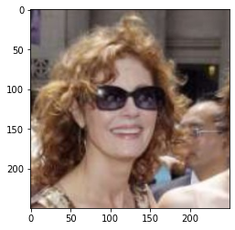

```
Hello, human!
If you were a dog..You may look like a Cavalier king charles spaniel
```

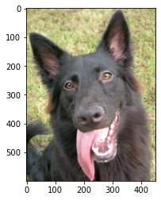

```
Dogs Detected!
It looks like a Belgian sheepdog
```

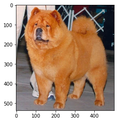

```
Dogs Detected!
It looks like a Chow chow
```

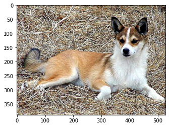

```
Dogs Detected!
It looks like a Norwegian lundehund
```

```python
app_human_files = ['./lfw/Zico/Zico_0002.jpg', './lfw/Willie_Nelson/Willie_Nelson_0001.jpg', './lfw/Susan_Sarandon/Susan_Sarandon_0004.jpg' ]
app_dog_files = ['./dogImages/test/021.Belgian_sheepdog/Belgian_sheepdog_01486.jpg', './dogImages/test/051.Chow_chow/Chow_chow_03660.jpg', './dogImages/test/110.Norwegian_lundehund/Norwegian_lundehund_07218.jpg']
for file in np.hstack((app_human_files[:3], app_dog_files[:3])):
                      run_app(file)
```